# Cognitive Bias Modification for social anxiety: a living systematic review and network meta-analysis

Jaycee Kennett, Virginia Chiocchia, Spyridon Siafis, Claire Friedrich, Simon E. Blackwell, Toshi Furukawa, Per Carlbring, Georgia Salanti, Andrea Cipriani, and the GALENOS team.

09 September 2026

# 1. Methods

In this first iteration of the living systematic review we searched for randomised controlled trials that compared Cognitive Bias Modification (CBM) to either control CBM or other CBM interventions. We searched for two populations: clinical (i.e. above-threshold symptoms on any standardised measure for social anxiety, or a clinical diagnosis of social anxiety based on any operationalised criteria); and non-clinical (individuals without above-threshold symptoms or a diagnosis of social anxiety but who were subjected to a social stressor).

## 1.1 Database searching and eligibility screening

Eight databases were searched from inception up to October, 2025 (see [protocol](https:///wellcomeopenresearch.org/articles/9-657/v1) for full search strings). Database search results were imported into [EPPI-Reviewer](https://eppi.ioe.ac.uk/cms/Default.aspx?tabid=2914) and duplicates were removed prior to screening. All steps related to record screening and data extraction were completed in [EPPI-Reviewer](https://eppi.ioe.ac.uk/cms/Default.aspx?tabid=2914).

Titles and abstracts of the identified records were screened by at least two reviewers (JK, CF, CM, SW, JP). We retrieved the full-texts and any supporting documents for all records that were not excluded at the title and abstract screening stage. The full-text screening was conducted by at least two reviewers (JK, CF, CM, SW, JP). Conflicts at title and abstract, and full-text screening were resolved through discussion between the two reviewers or involvement of a third reviewer.

## 1.2 Extraction of outcome data

The primary outcome was social anxiety symptom severity using social anxiety-specific scales (observer-rated or self-rated) or, in the non-clinical population, social anxiety-related symptoms.  
The secondary outcomes were the following:

- depression symptom severity, as per observer or self-reported standardised scales;
- general anxiety symptom severity, as per observer or self-reported standardised scales;
- change in cognitive bias, as per observer or self-reported standardised scales;
- quality of life, as per observer or self-reported standardised scales;
- acceptability, as proportion of participants dropping out for any reason;
- tolerability, as proportion of participants dropping out due to an adverse event;
- adverse events reported by the study.

Details of outcome prioritisation and additional information on the full study eligibility criteria can be found in the pre-published [protocol](https:///wellcomeopenresearch.org/articles/9-657/v1).

For social anxiety, depression, general anxiety symptom, change in bias, and quality of life, we extracted outcome data reported at the closest post-intervention time point. If data collected immediately post-intervention weeks was not available, we considered eligible data after the intervention (with preference to the time point closest to the end of the intervention). For acceptability, tolerability, safety and adverse events, we extracted outcome data reported at the end of the studies.

When extracting continuous outcomes we extracted mean and standard deviation to two decimal places. Where standard error was reported, we converted the value to standard deviation. Baseline and endpoint values were extracted. These were preferred to change in score and endpoint, in which case the missing value was calculated by adding or subtracting the change in score from the time point given.

When extracting dichotomous outcomes we extracted absolute numbers and, where only percentages of participant groups were reported, the absolute number was calculated and rounded up to the nearest integer. Adverse events were extracted using the exact wording used to report them in the included studies.

Relevant data was extracted using [EPPI-Reviewer](https://eppi.ioe.ac.uk/cms/Default.aspx?tabid=2914) by at least two reviewers (JK, CF, SW, CM, JP). EPPI-Reviewer was used to screen records, extract data, and assess risk of bias.

## 1.3 Analysis

We conducted pairwise meta-analysis for all outcomes for CBM versus control. As the types of CBM and types of controls were heterogeneous, we then conducted a network meta-analysis (NMA) to establish the relative effects of CBM interventions and their respective controls for both the clinical and non-clinical sources of evidence.

Effect sizes were calculated as standardised mean differences (SMDs) for continuous outcomes (social anxiety, depression, and general anxiety symptom severity, change in bias, and quality of life) and odds ratios (ORs) for dichotomous outcomes (acceptability, tolerability, and specific-adverse events). We calculated the 95% confidence interval (CI) around each pooled effect size. We used the Hartung-Knapp correction for the 95% CI where more than five studies contributed to the analysis.

For the pairwise meta-analysis, we used a frequentist random effects model for all CBM interventions versus control conditions. Heterogeneity was assessed by visual inspection of forest plots and presented by the 95% prediction intervals (PI). Heterogeneity (tau<sup>2</sup>) was estimated using restricted maximum likelihood (REML). We assumed a common heterogeneity parameter (tau<sup>2</sup>) across treatment comparisons in the NMA random effects model. For NMA we used a random effects model, separating the different control conditions and the different CBM approaches. We evaluated inconsistency in the network using both local (separate indirect from direct evidence (SIDE) method) and global (design-by-treatment interaction) tests. Relative treatment effects are reported in forest plots and league tables, with treatments ordered according to ranking based on the surface under the cumulative ranking curve (SUCRA) (Salanti, Ades, & Ioannidis, 2011).

We performed subgroup analysis comparing a) single versus multi-session interventions b) CBM mode of delivery, and c) studies where an author has an allegiance bias (is involved in the CBM intervention that is tested). Presence of an allegiance bias was determined by identifying all studies reporting a conflict of interest and examining whether the reported conflict stated that an author was involved in the development of CBM interventions.

## 1.4 Classification of CBM subtypes

The classification of CBM interventions and control conditions was decided at an adjudication meeting of topic experts and methodologists (TF, PC, SB, VC).The lead author classified interventions and control conditions based on the information provided in the study texts and our pre-specified classifications of expected interventions in our protocol (Kennett et al., 2025). These were distributed to the expert team prior to the meeting. In the meeting, uncertainties and outstanding interventions were discussed before finalising all classifications.

The team was able to unanimously classify each intervention and control condition after deliberation aside from Heeren et al (2011) and Ferrari et al (2018). In the case of Heeren et al (2011), the study consisted of four arms: a standard cognitive bias modification for attention (CBM-A) arm, a control CBM-A arm, and two arms which replicated different parts of the CBM-A intervention. This dismantling of the standard CBM-A procedure created two interventions which were neither fully CBM nor fully control. As such, it was decided at the adjudication meeting to not include these arms in the analysis and analyse only the standard CBM-A and CBM-A control arms. Similarly, Ferrari et al (2018) used a standard approach-avoidance training (AAT) procedure, a control AAT procedure, and two arms which replicated different parts of the AAT intervention in an attempt to dismantle the intervention and test the effects of its individual mechanisms. These arms were subsequently excluded from analysis. Descriptions of the final CBM subtypes can be found in table 1 in section 1.7.

## 1.5 Risk of bias

We assessed the risk of bias for all studies at study level using the RoB2 tool (Sterne et al. 2019). The overall risk of bias was graded as: low risk, if no domains were rated high risk and no more than one domain was rated some concerns; high risk, if any domain was rated high risk; and some concerns, if more than one domain was rated as having some concerns and no domains were rated high risk. All outcomes for all included studies were assessed by at least two reviewers (JK, CF, CM, SW, JP) and conflicts were resolved by discussion between reviewers.

The risk of bias due to missing evidence in our network was completed in consultation with topic experts using the Risk of Bias due to Missing Evidence in NMA (ROB-MEN) tool (Chioccchia et al., 2021). The analyses within the ROB-MEN app were conducted choosing a random effects model with a burn-in of 1000, 10000 iterations, a thinning factor of 1, and the assumption of exchangeable treatment-specific interactions. Control CBM-A was used at the reference treatment, smaller values were specified as desirable, and SMD was used as the effect size. In the ROB-MEN table, we considered the contribution from biased evidence to be substantially in favour of one intervention if the relative difference between interventions was at least 15%. The final overall level of risk of bias due to missing evidence in each network estimate was automatically calculated by the ROB-MEN app.

## 1.6 Confidence in the evidence

Indirectness at the study level was judged qualitatively in conjunction with topic experts. The ‘average indirectness’ rule implemented in the CINeMA app was used to assign a level of ‘no concerns’, ‘some concerns’, or ‘major concerns’ to each comparison.

For assessing imprecision, heterogeneity, and incoherence a SMD of 0.24 was set as a conservative clinically important size of effect. This was determined based on the minimum clinically important difference suggested for improvements in general anxiety on standardised scales (Toussaint er al., 2020; Kroenke et al., 2019) and for psychological interventions in other mental health conditions (Cuijpers et al., 2014). The ratings of ’no concerns’, ‘some concerns’, or ‘major concerns’ for each comparison were automatically generated by the CINeMA app.

To reach an overall level of confidence for each comparison we applied the following rules, in line with other NMAs using CINeMA (Schneider-Thoma et al., 2022; Bighelli et al., 2021). Possible levels of confidence were ‘high’, ‘moderate’, ‘low’, and ‘very low’. All overall levels of confidence were by default high for every comparison but were downgraded depending on the individual ratings for each domain. If any one domain rating for a comparison was ‘major concerns’, the overall level of confidence for that comparison was downgraded by two levels, and where two domain ratings were ‘major concerns’ and an additional rating was either ‘some concerns’ or ‘major concerns’, the comparison was downgraded by three levels. If a comparison contained any domain rating of ‘some concerns’, it was downgraded by one level. Domain ratings were considered jointly and multiple ratings of ‘some concerns’ (and no ratings of ‘major concerns’) for a comparison were not used as justification for downgrading by more than one level, as they may be interconnected. Similarly, two ratings of ‘major concerns’ and no further ratings of ‘some concerns’ or ‘major concerns’ were not used as justification for downgrading by more than two levels.

Please refer to the [protocol](https:///wellcomeopenresearch.org/articles/9-657/v1) for more details.

A list of included studies, tables, and a list of abbreviations can be found at the end of the document.

## 1.7 Description of CBM subtypes

While all of the CBM interventions in our review targeted a specific cognitive bias by repeatedly exposing individuals to tasks that promote patterns of selective processing, they formed distinct subtypes.

Our CBM-A node was characterised by interventions which seek to train an individual’s attention away from negative stimuli. While they differ in format (e.g. length of the training sessions or mode of delivery) they all use faces and words appearing for around 500ms as stimuli. Control CBM-A is a ‘sham’ condition that replicates the procedure of CBM-A but the tasks are neutral (i.e. they do not aim to direct attention). Opposite CBM-A also replicates the CBM-A process but aims to train individuals’ attention towards negative stimuli.

Cognitive bias modification for interpretation (CBM-I) uses similar training procedures to CBM-A but instead repeatedly asks individuals to use words to finish ambiguous sentences to promote positive interpretation of neutral or negative scenarios. Control CBM-I replicates this procedure but does not aim to change the way that individuals interpret information; opposite CBM-I used the same procedure as CBM-I but aims to train individuals to interpret information more negatively.

Multicomponent CBM combines both CBM-I and CBM-A procedures, usually in a single session and so attempts to target both biases. It is often accompanied by a ‘combined control’ procedure where the multicomponent CBM training procedure is replicated but without aiming to modify any bias.

Approach avoidance training (ATT) aims to train individual’s action biases away from approaching negative stimuli, using repeated tasks with a joystick to push or pull away from negative words, faces, or images. Control AAT replicates this procedure but does not aim to systematically retrain any bias.

Each intervention and its respective classification can be found in table 1.

| **Intervention** | **Node** |
| --- | --- |
| AAT (Approach-Avoidance Training) | AAT |
| AAT balanced/positive-negative |  |
| ABM (2D stimuli) | CBM-A |
| ABM (3D stimuli) |  |
| ABM contingency |  |
| ABM disengage/re-engage |  |
| ABM/CBM-A (Attention Bias Modification) |  |
| Attention Modification Program (AMP) |  |
| CBM-A |  |
| GC-MRT (Gaze-Contingent Music Reward Therapy) |  |
| Benign (non-negative) CBM-I | CBM-I |
| Benign CBM-I |  |
| CBM-I |  |
| CBM-I with expectancy induction |  |
| CBM-I + imaginal exposure |  |
| CBM-I with feedback |  |
| CBM-I + neutral thinking |  |
| CBM-I + relaxation |  |
| CBM-IS (CBM intepretation of the self) |  |
| Explicit CBM-I |  |
| IBM/CBM-I (Interpretive Bias Modification) |  |
| IMP (Interpretation Modification Program) |  |
| Positive CBM-I |  |
| Relaxation + CBM-I |  |
| Combined control | Combined control |
| Control AIM |  |
| Control AAT | Control AAT |
| Control AAT (Approach-Avoidance Training) |  |
| ABM non-contingency | Control CBM-A |
| Attention Control Condition (ACC) |  |
| Control ABM |  |
| Control CBM-A |  |
| GC-MRT (Gaze-Contingent Music Reward Therapy) - shapes |  |
| Non-valence specific ABM |  |
| Control CBM-I | Control CBM-I |
| Control CBM-IS (CBM interpretation of the self) |  |
| ICC (Interpretation Control Condition) |  |
| AIM (Attention Interpretation Modification) | Multicomponent |
| CBM-A + CBM-I |  |
| Multi-component/Combination CBM |  |
| Opposite ABM/CBM-A | Opposite CBM-A |
| Opposite CBM-A |  |
| Opposite IBM/CBM-I | Opposite CBM-I |
| Opposite CBM-I |  |
| Treatment as usual (TAU) | TAU |
| Waitlist | Waitlist |

**Table 1.** Interventions used in the included papers and their respective intervention classifications

# 2. Results

## 2.1 PRISMA Flow diagram

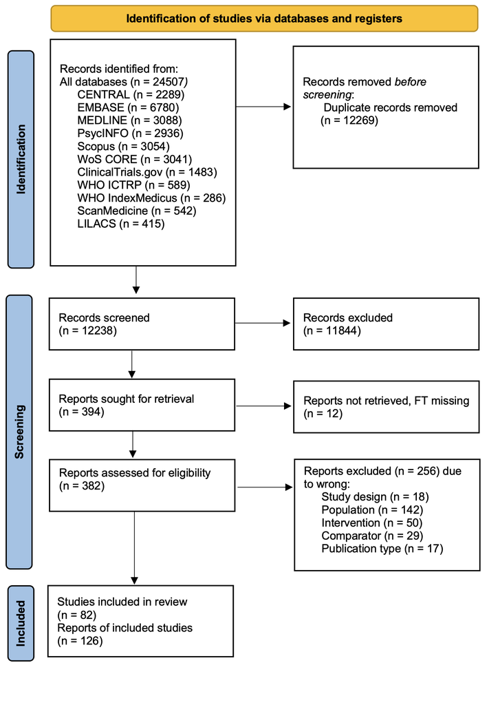

**Figure 1.** PRISMA 2020 flow diagram.

## 2.2 Description of included studies

We identified 82 eligible studies. The characteristics of the identified studies can be found in **Table 7.** 55 studies contributed data to at least one outcome (total of 4247 participants). 48 studies contributed to the clinical source of evidence (total of 3373 participants) and 7 studies contributed to the non-clinical source of evidence (total of 874 participants).

The mean age of participants in the clinical source was 23.4 with a mean proportion of 69.6% female participants. The mean age of the participants in the non-clinical source was 22.9 years. with a mean proportion of 46.1% female participants.

## 2.3 Clinical population

### 2.3.1 Social anxiety

#### 2.3.1.1 Pairwise meta-analysis

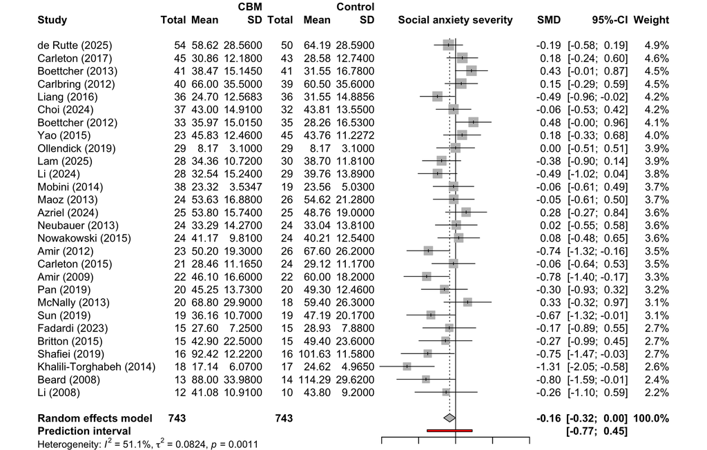

**Figure 2.** Forest plot for social anxiety scores (primary outcome) comparing CBM versus control in individuals with social anxiety. SMD: standardised mean difference, CI: confidence intervals, SD: standard deviation.

The effect of CBM versus control in the clinical source showed an SMD of -0.16 (95% CI: -0.32 to 0). There is considerable heterogeneity as shown by the 95% prediction interval ranging from -0.77 to 0.45.

#### 2.3.1.2 Network meta-analysis

As there was a high amount of heterogeneity in the interventions and controls used in the included studies, network meta-analysis was conducted to establish the relative effects of CBM subtypes and individual controls. The network consisted of 39 studies, 52 comparisons and 10 treatments. In order to construct the network, two studies were removed (Asaani 2014; Bomyea 2023) as they only compared approach avoidance training (AAT) with control AAT and were disconnected from the rest of the network.

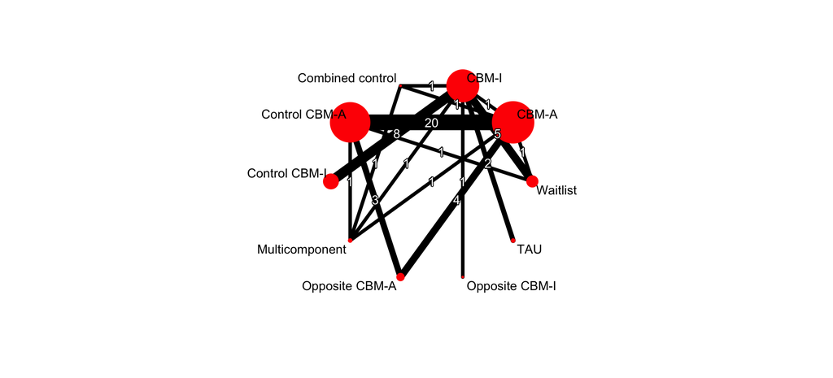

**Figure 3.** Network plot of CBM interventions for social anxiety. CBM-I = Cognitive Bias Modification for Interpretations; CBM-A = Cognitive Bias Modification for Attention; TAU = Treatment As Usual; Opposite CBM-I = Opposite Cognitive Bias Modification for Interpretations; Opposite CBM-A = Opposite Cognitive Bias Modification for Attention; Multicomponent = Multicomponent CBM; Control CBM-I; Control CBM-I = Control Cognitive Bias Modification for Interpretations; Control CBM-A = Control Cognitive Bias Modification for Attention.

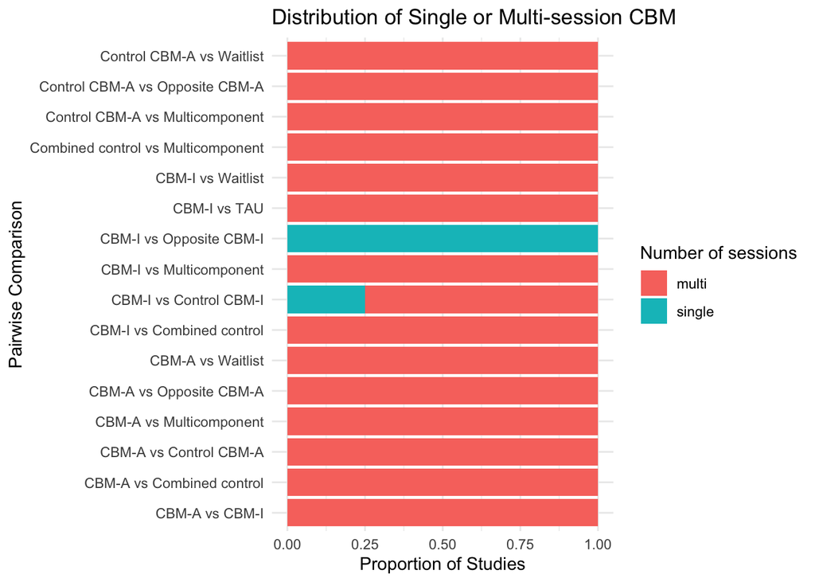

**Figure 4.** Barplot of the distribution of the effect modifier number of sessions across pairwise comparisons

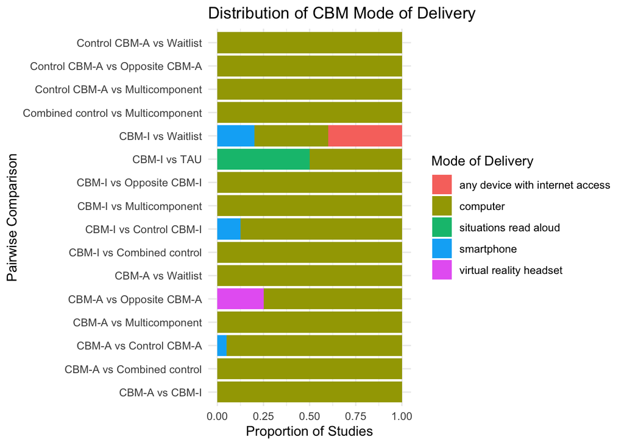

**Figure 5.** Barplot of the distribution of the effect modifier mode of delivery across pairwise comparisons

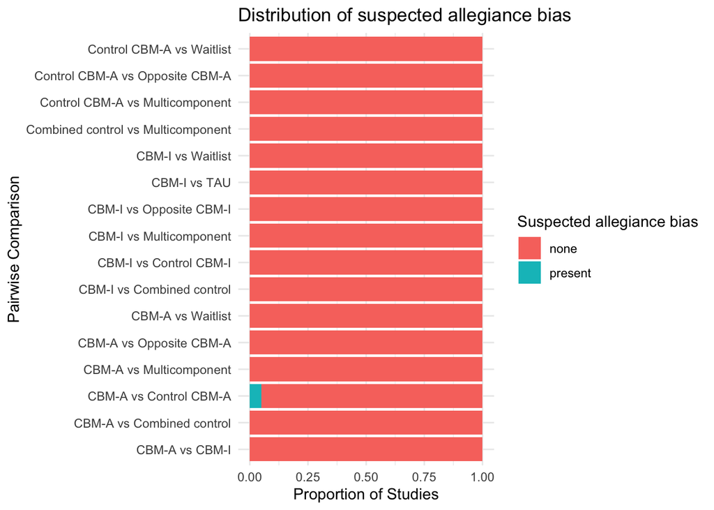

Due to this relatively homogeneous distribution of effect modifiers and the qualitative similarity between population, intervention, comparator, and outcome among comparisons in the network, we judged transitivity to be plausible.

We found effects across CBM interventions versus Control CBM-A to range from 1.19 (SMD, 95% CI: -0.12 to 2.5, 95% PI: -0.44 to 2.83) in Opposite CBM-I to -0.18 (SMD, 95% CI: -0.41 to 0.05, 95% PI: -1.12 to 0.76) in CBM-A. The heterogeneity standard deviation is estimated at 0.45.

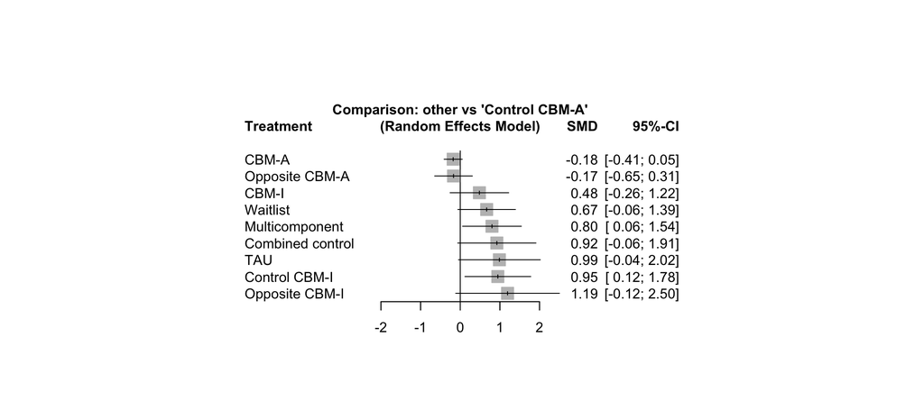

**Figure 7.** Relative treatment effects for social anxiety scores of each intervention versus control CBM-A

All relative treatment effects estimated in the NMA for social anxiety scores are presented in the lower triangle of Table 2 (league table).

| . | CBM-A | CBM-I | Combined control | Control CBM-A | Control CBM-I | Multicomponent | Opposite CBM-A | Opposite CBM-I | TAU | Waitlist |
| --- | --- | --- | --- | --- | --- | --- | --- | --- | --- | --- |
| CBM-A | CBM-A | -1.73 [-2.84; -0.63] | -2.17 [-3.30; -1.04] | -0.10 [-0.34; 0.13] | NA | -2.92 [-4.09; -1.76] | 0.10 [-0.41; 0.60] | NA | NA | -0.85 [-1.93; 0.23] |
| CBM-I | -0.66 [-1.39; 0.07], [-1.85; 0.52] | CBM-I | -0.44 [-1.51; 0.64] | NA | -0.47 [-0.84; -0.09] | -1.19 [-2.27; -0.10] | NA | -0.71 [-1.79; 0.37] | -0.50 [-1.22; 0.22] | -0.20 [-0.68; 0.28] |
| Combined control | -1.10 [-2.08; -0.12], [-2.47; 0.26] | -0.44 [-1.44; 0.56], [-1.82; 0.94] | Combined control | NA | NA | -0.75 [-1.83; 0.33] | NA | NA | NA | NA |
| Control CBM-A | -0.18 [-0.41; 0.05], [-1.12; 0.76] | 0.48 [-0.26; 1.22], [-0.71; 1.67] | 0.92 [-0.06; 1.91], [-0.45; 2.29] | Control CBM-A | NA | 0.63 [-0.38; 1.64] | -0.01 [-0.60; 0.59] | NA | NA | -0.53 [-1.60; 0.54] |
| Control CBM-I | -1.13 [-1.95; -0.30], [-2.38; 0.12] | -0.47 [-0.84; -0.09], [-1.46; 0.53] | -0.02 [-1.10; 1.05], [-1.46; 1.41] | -0.95 [-1.78; -0.12], [-2.20; 0.31] | Control CBM-I | NA | NA | NA | NA | NA |
| Multicomponent | -0.98 [-1.73; -0.23], [-2.18; 0.22] | -0.32 [-1.19; 0.55], [-1.60; 0.96] | 0.12 [-0.87; 1.12], [-1.25; 1.50] | -0.80 [-1.54; -0.06], [-1.99; 0.39] | 0.15 [-0.80; 1.10], [-1.19; 1.49] | Multicomponent | NA | NA | NA | NA |
| Opposite CBM-A | -0.01 [-0.47; 0.45], [-1.04; 1.02] | 0.65 [-0.20; 1.51], [-0.62; 1.93] | 1.09 [0.02; 2.17], [-0.35; 2.53] | 0.17 [-0.31; 0.65], [-0.87; 1.21] | 1.12 [0.18; 2.05], [-0.21; 2.45] | 0.97 [0.10; 1.84], [-0.31; 2.25] | Opposite CBM-A | NA | NA | NA |
| Opposite CBM-I | -1.37 [-2.68; -0.07], [-3.00; 0.26] | -0.71 [-1.79; 0.37], [-2.15; 0.73] | -0.27 [-1.74; 1.20], [-2.05; 1.51] | -1.19 [-2.50; 0.12], [-2.83; 0.44] | -0.25 [-1.39; 0.90], [-1.74; 1.25] | -0.39 [-1.78; 0.99], [-2.09; 1.31] | -1.36 [-2.74; 0.02], [-3.06; 0.33] | Opposite CBM-I | NA | NA |
| TAU | -1.17 [-2.19; -0.14], [-2.57; 0.23] | -0.50 [-1.22; 0.22], [-1.68; 0.67] | -0.06 [-1.30; 1.17], [-1.63; 1.51] | -0.99 [-2.02; 0.04], [-2.39; 0.42] | -0.04 [-0.85; 0.77], [-1.28; 1.20] | -0.19 [-1.32; 0.94], [-1.67; 1.30] | -1.16 [-2.28; -0.04], [-2.63; 0.32] | 0.21 [-1.09; 1.50], [-1.42; 1.83] | TAU | NA |
| Waitlist | -0.85 [-1.57; -0.12], [-2.02; 0.33] | -0.18 [-0.64; 0.27], [-1.21; 0.84] | 0.26 [-0.79; 1.30], [-1.16; 1.67] | -0.67 [-1.39; 0.06], [-1.85; 0.52] | 0.28 [-0.31; 0.87], [-0.82; 1.38] | 0.13 [-0.76; 1.03], [-1.17; 1.44] | -0.84 [-1.68; 0.01], [-2.10; 0.43] | 0.53 [-0.65; 1.70], [-0.99; 2.04] | 0.32 [-0.53; 1.17], [-0.95; 1.59] | Waitlist |

**Table 2.** League table for social anxiety scores. Lower triangle shows the relative treatment effects estimated in the NMA; upper triangle shows the pairwise meta-analysis (direct) estimates. The effects are presented as SMD, 95% CI, and 95% PI. Negative values favour the treatment in the column.

#### 2.3.1.3 Inconsistency assessment

There is some evidence of inconsistency in the data. There were in total 13 different treatment comparisons included in loops in the network, and there was inconsistency (according to SIDE p-value<0.10) in 7, equal to 54%.

The p-value from the design-by-treatment test to evaluate global inconsistency is 0.

#### 2.3.1.5 Risk of bias

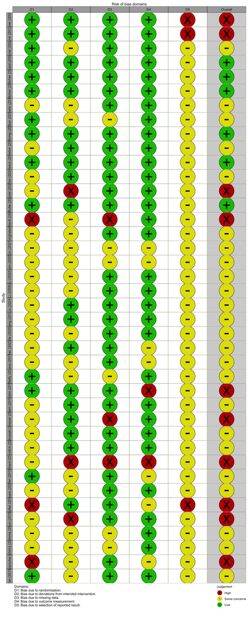

**Figure 8.** Risk of bias assessment for each study contributing data on social anxiety using the RoB2 tool

10 studies (29%) were assessed as having ‘high’ risk of bias due to having ‘high’ risk of bias in at least one domain. 19 studies (56%) had an overall ‘moderate’ risk of bias rating as they had ‘some concerns’ in two domain ratings. The remaining 5 studies were rated as having a ‘low’ overall risk of bias.

#### 2.3.1.6 Sensitivity analysis

We conducted a sensitivity analysis for our primary outcome using two pre-specified factors: 1) excluding studies with a high risk of bias and 2) restricting the analysis to studies that recruited participants with a diagnosis of social anxiety disorder (determined by a clinical interview).

Having excluded studies with high risk of bias, the network consisted of 29 studies, 42 comparisons and 9 treatments.

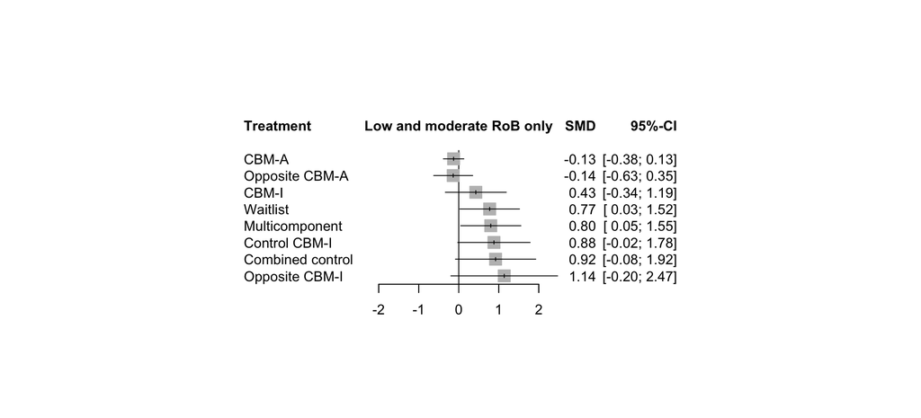

**Figure 9.** Sensitivity analysis of reduction in social anxiety scores following CBM in a population with social anxiety, excluding studies rated at high risk of bias (reference control CBM-A).

Having restricted the analysis to studies with participants diagnosed with social anxiety disorder, the network consisted of 9 studies, 16 comparisons and 8 treatments.

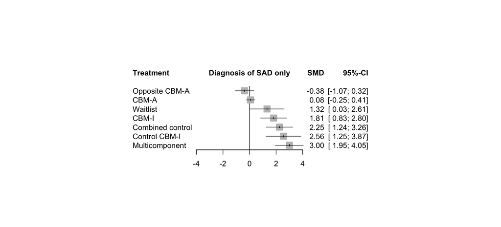

**Figure 10** Sensitivity analysis of reduction in social anxiety scores following CBM in a population with social anxiety, restricting to studies that exclusively recruited individuals with a diagnosis of social anxiety disorder (SAD) (reference control CBM-A).

The sensitivity analyses closely replicated the main results. There was little difference between CBM-A, control CBM-A, and opposite CBM-A whereas CBM-I was consistently superior to its matched control.

#### 2.3.1.7 Reporting bias

The details of the ROB-MEN assessments are reported below. See table 8 for the pairwise comparison table and table 9 for the ROB-MEN Table reporting the overall judgement of risk of bias due to missing evidence.

**Within-study bias:**

Using the ROB-MEN app, the rating ‘no bias detected’ was given if no study within that comparison was suspected of under reporting (or selective non reporting) of results and if there were no extra studies in the comparisons (those identified in the review that reported other outcomes but not social anxiety). Five studies included in the review could not be included in the synthesis for social anxiety. These contributed to the following comparisons: CBM-A versus control CBM-A; CBM-A versus opposite CBM-A; opposite CBM-A versus control CBM-A; and CBM-I versus control CBM-I. We found these studies to be potentially biased because they reported non-significant decrease in social anxiety symptom severity compared to the control intervention but did not report values that could be included in the synthesis. We then assessed the potential impact of these missing results by considering the amount of missing data (in terms of additional sample size) compared to the sample size included in the synthesis for social anxiety for that comparison (columns 2 and 3 in table 8). We rated these four comparisons as suspected bias towards the active intervention (CBM-A or CBM-I).

**Across-study bias:**

CBM is a new field where many trials are run by universities without industrial funding and few have published protocols; this meant we were not able to restrict our inclusion criteria to prospectively registered studies and it increases the possibility that studies may have been conducted but not published due to non-significant results. In addition, it is common for novel CBM interventions to be trialled and then discontinued if they do not perform positively. As such, in consultation with a topic expert, we rated all comparisons with an active CBM intervention (i.e. not control or opposite CBM) to be at suspected risk of across-study bias in favour of the active intervention. All other comparisons were given the rating ‘no bias detected’ (see table 8 in section 4 ).

**Evaluation of contribution from evidence with suspected bias:**

In the evaluation of contribution of evidence from pairwise comparisons with suspected bias (see columns 2 and 3 in table 9 in section 4), if the relative difference in the contribution of biased evidence between interventions was at least 15%, we considered the comparison to be substantially biased in favour of the intervention with the greatest contribution of biased evidence. Two comparisons were rated with substantial biased contribution favouring CBM-A: CBM-A versus control CBM-A and CBM-A versus opposite CBM-A. Two comparisons were judged to have substantial contribution biased towards CBM-I: CBM-I versus control CBM-I; CBM-I versus opposite CBM-I. A further three comparisons were rated to have a substantial contribution biased towards opposite CBM-A: control CBM-A versus opposite CBM-A; multicomponent versus opposite CBM-A; and opposite CBM-A versus waitlist.

**Evaluation of small-study effects:**

- CBM-A versus TAU, and CBM-A versus multicomponent CBM were rated as small-study effects favouring CBM-A.
- Control CBM-A versus multicomponent CBM, CBM-I versus control CBM-A, and control CBM-A versus TAU were rated as small-study effects favouring control CBM-A.
- CBM-I versus opposite CBM-A, multicomponent CBM versus opposite CBM-A, and opposite CBM-A versus TAU were rated as small-study effects favouring opposite CBM-A.
- CBM-A versus CBM-I was rated as small-study effects towards opposite CBM-I.
- Multicomponent CBM versus waitlist was rated as small-study effects favouring waitlist.

There was a good overlap between the credible intervals of each pair of adjusted and unadjusted estimates for the other comparisons so they were rated as no evidence of small-study effects.

**Overall ROB-MEN ratings:**

Overall, nine comparisons were rated as some concerns: CBM-A versus CBM-I; CBM-A versus Control CBM-A; CBM-A versus Multicomponent; CBM-A versus Opposite CBM-A; CBM-I versus Control CBM-I; CBM-I versus Opposite CBM-I; Control CBM-A versus Multicomponent; Control CBM-A versus Opposite CBM-A; Opposite CBM-A versus Waitlist One comparison was rated as high risk: multicomponent versus opposite CBM-A. The remaining were rated as low risk. Ratings for each domain within ROB-MEN for each comparison are shown in table 9 in section 4.

#### 2.3.1.8 Confidence in the evidence

Details of the methods used to assess confidence in the evidence can be found in section 1.6. Table 10 in section 5 contains all domain ratings for the CINeMA tool.

For the within-study bias domain in the CINeMA tool, four comparisons were assessed to have major concerns (TAU versus waitlist, CBM-I versus TAU, control CBM-I versus TAU, opposite CBM-I versus TAU) whereas the remaining comparisons were assessed to have some concerns due to within-study bias.

The ROB-MEN final judgements were used as the reporting bias ratings in CINeMA (see section 2.3.1.7 for ROB-MEN ratings).

For indirectness, we judged whether the study population, interventions, outcomes, and study settings were directly relevant for the research questions. In terms of population, studies were only eligible if the participants had social anxiety, measured by a standardised scale or diagnostic interview. We judged this population to be directly relevant to the research question. All of the interventions in the included studies aimed to change a cognitive bias via repeated task and were confirmed to be relevant by a panel of topic experts. We judged these as also being directly relevant to the research question. The outcomes within our review were all validated scales used to measure social anxiety and so are relevant to the research question. As all of these aspects of our included studies were directly relevant to the research question, we rated all comparisons as low risk for indirectness.

Eight comparisons were judged to have major concerns due to heterogeneity: CBM-A versus multicomponent; CBM-A versus waitlist; CBM-I versus control CBM-I; CBM-A versus opposite CBM-I; CBM-A versus TAU; control CBM-A versus control CBM-I; control CBM-I versus opposite CBM-A; and opposite CBM-A versus control CBM-I. 15 comparisons were rated as some concerns due to heterogeneity, while 22 were rated as no concerns.

For incoherence, 38 comparisons were rated as major concerns, CBM-A versus, control CBM-A was rated as some concerns was and the remaining six were judged to have no concerns due to incoherence. These were: CBM-A versus opposite CBM-A; CBM-A versus waitlist; CBM-I versus combined control; CBM-I versus waitlist; control CBM-A versus opposite CBM-A; and control CBM-A versus waitlist.

Using the process described in section 1.6, three comparisons (CBM-A versus control CBM-A, CBM-A versus opposite CBM-A, and control CBM-A versus waitlist) were judged to have moderate confidence, 15 were judged to have low confidence, and 27 were judged to have very low confidence. All CINeMA ratings and reasons for downgrading can be found in table 10 in section 5.

### 2.3.2 Depression

#### 2.3.2.1 Pairwise meta-analysis

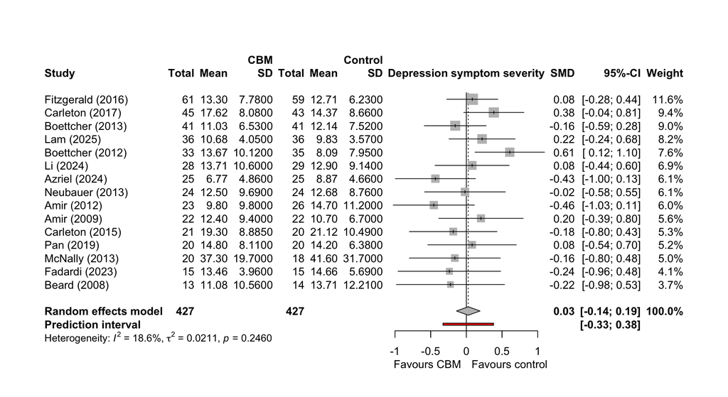

**Figure 11.** Forest plot for symptoms of depression (secondary outcome) comparing CBM vs control for individuals with social anxiety post intervention . SMD: standardised mean difference, 95% CI: 95% confidence intervals, SD: standard deviation.

The effect of CBM versus control in the clinical source showed a SMD of 0.03 (95% CI: -0.14 to 0.19). There is some heterogeneity as shown by the 95% prediction interval ranging from -0.33 to 0.38.

#### 2.3.2.2 Network meta-analysis

As there was a high amount of heterogeneity in the interventions and controls used in the included studies, network meta-analysis was conducted to establish the relative effects of CBM subtypes and individual controls. The network consisted of 21 studies, 29 comparisons and 8 treatments. In order to construct the network, two studies were removed (Asaani 2014; Bomyea 2023) as they only compared approach avoidance training (AAT) with control AAT and were disconnected from the rest of the network.

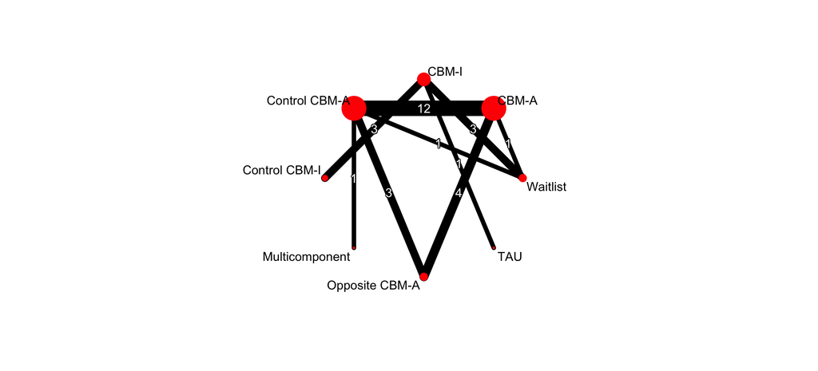

**Figure 12.** Network plot of CBM interventions for symptoms of depression.CBM-I = Cognitive Bias Modification for Interpretations; CBM-A = Cognitive Bias Modification for Attention; TAU = Treatment As Usual; Opposite CBM-I = Opposite Cognitive Bias Modification for Interpretations; Opposite CBM-A = Opposite Cognitive Bias Modification for Attention; Multicomponent = Multicomponent CBM; Control CBM-I; Control CBM-I = Control Cognitive Bias Modification for Interpretations; Control CBM-A = Control Cognitive Bias Modification for Attention.

We found effects across CBM interventions versus Control CBM-A to range from 0.55 (SMD, 95% CI: -0.29 to 1.4, 95% PI: -0.44 to 1.54 ) in Control CBM-I to 0.04 (SMD, 95% CI: -0.14 to 0.22, 95% PI: -0.41 to 0.49) in CBM-A. The heterogeneity standard deviation is estimated at 0.194.

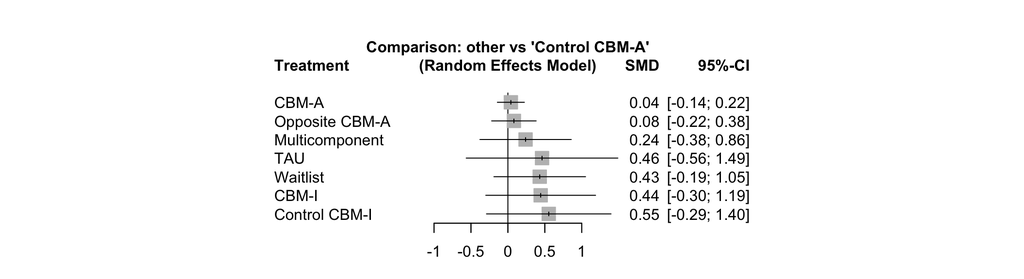

**Figure 13.** Relative treatment effects for symptoms of depression of each intervention versus Control CBM-A

All relative treatment effects estimated in the NMA for depression scores are presented in the lower triangle of Table 3 (league table).

| . | CBM-A | CBM-I | Control CBM-A | Control CBM-I | Multicomponent | Opposite CBM-A | TAU | Waitlist |
| --- | --- | --- | --- | --- | --- | --- | --- | --- |
| CBM-A | CBM-A | NA | 0.04 [-0.14; 0.23] | NA | NA | -0.08 [-0.39; 0.22] | NA | -0.37 [-1.08; 0.34] |
| CBM-I | -0.40 [-1.15; 0.34], [-1.30; 0.49] | CBM-I | NA | -0.11 [-0.51; 0.29] | NA | NA | -0.02 [-0.73; 0.69] | 0.01 [-0.40; 0.42] |
| Control CBM-A | 0.04 [-0.14; 0.22], [-0.41; 0.49] | 0.44 [-0.30; 1.19], [-0.45; 1.34] | Control CBM-A | NA | -0.24 [-0.86; 0.38] | -0.01 [-0.38; 0.36] | NA | -0.45 [-1.16; 0.26] |
| Control CBM-I | -0.51 [-1.36; 0.33], [-1.50; 0.48] | -0.11 [-0.51; 0.29], [-0.70; 0.48] | -0.55 [-1.40; 0.29], [-1.54; 0.44] | Control CBM-I | NA | NA | NA | NA |
| Multicomponent | -0.20 [-0.84; 0.45], [-1.00; 0.60] | 0.20 [-0.76; 1.17], [-0.91; 1.32] | -0.24 [-0.86; 0.38], [-1.02; 0.54] | 0.31 [-0.73; 1.36], [-0.88; 1.51] | Multicomponent | NA | NA | NA |
| Opposite CBM-A | -0.04 [-0.33; 0.25], [-0.55; 0.47] | 0.36 [-0.43; 1.15], [-0.58; 1.30] | -0.08 [-0.38; 0.22], [-0.60; 0.44] | 0.47 [-0.41; 1.35], [-0.56; 1.50] | 0.16 [-0.53; 0.85], [-0.68; 1.00] | Opposite CBM-A | NA | NA |
| TAU | -0.42 [-1.45; 0.60], [-1.59; 0.75] | -0.02 [-0.73; 0.69], [-0.88; 0.84] | -0.46 [-1.49; 0.56], [-1.64; 0.71] | 0.09 [-0.72; 0.90], [-0.87; 1.05] | -0.22 [-1.42; 0.98], [-1.57; 1.12] | -0.38 [-1.44; 0.68], [-1.59; 0.83] | TAU | NA |
| Waitlist | -0.39 [-1.01; 0.23], [-1.17; 0.39] | 0.01 [-0.40; 0.42], [-0.59; 0.61] | -0.43 [-1.05; 0.19], [-1.21; 0.35] | 0.12 [-0.45; 0.69], [-0.61; 0.86] | -0.19 [-1.07; 0.68], [-1.21; 0.83] | -0.35 [-1.02; 0.32], [-1.18; 0.48] | 0.03 [-0.79; 0.85], [-0.94; 1.00] | Waitlist |

**Table 3.** League table for depression scores. Lower triangle shows the relative treatment effects estimated in the NMA; upper triangle shows the pairwise meta-analysis (direct) estimates. The effects are presented as SMD, 95% CI, and 95% PI. Negative values favour the treatment in the column.

#### 2.3.2.3 Inconsistency assessment

There were in total 5 different treatment comparisons included in loops in the network, and there is inconsistency (according to SIDE p-value<0.10) in 0, equal to 0%.

The p-value from the design-by-treatment test to evaluate global inconsistency is 0.93.

#### 2.3.2.4 Risk of bias

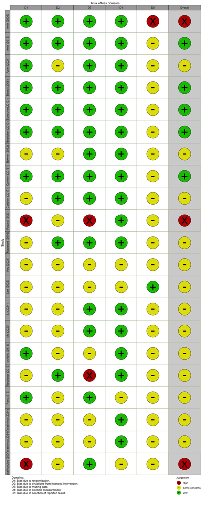

**Figure 14.** Risk of bias assessment for each study contributing data on depression using the RoB2 tool

### 2.3.3 General anxiety

#### 2.3.3.1 Pairwise meta-analysis

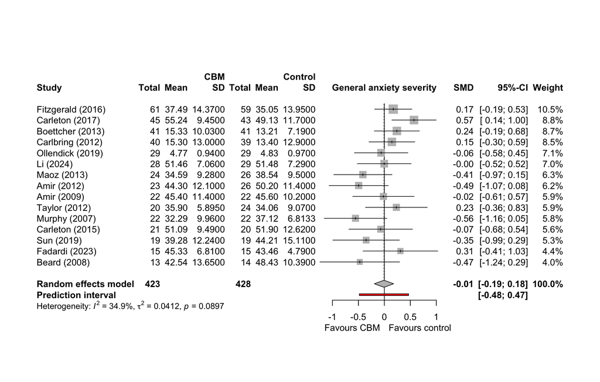

**Figure 15.** Forest plot for general anxiety scores (secondary outcome) comparing CBM versus control post intervention in individuals with social anxiety. SMD: standardised mean difference, 95% CI: 95% confidence intervals, SD: standard deviation.

The effect of CBM versus control in the clinical source showed a SMD of -0.01 (95% CI: -0.19 to 0.18). There is some heterogeneity as shown by the 95% prediction interval ranging from -0.48 to 0.47.

#### 2.3.3.2 Network meta-analysis

As there was a high amount of heterogeneity in the interventions and controls used in the included studies, network meta-analysis was conducted to establish the relative effects of CBM subtypes and individual controls. This showed three disconnected networks. Subnetwork 3 was not analysed as it only contained 1 study and the remaining subnetworks were analysed separately.

Subnetwork 1 consisted of 12 studies, 16 comparisons and 4 treatments. Subnetwork 2 consisted of 6 studies, 6 comparisons and 3 treatments.

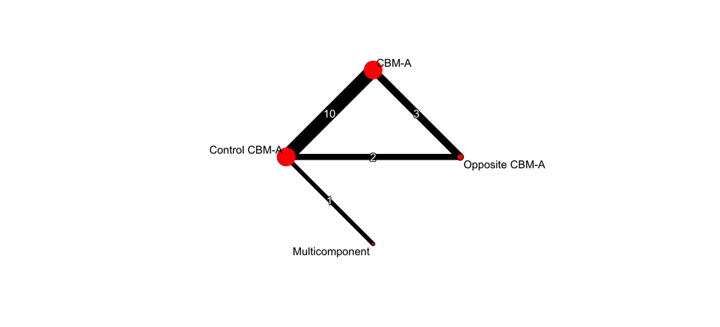

**Figure 16.** Network (subnetwork 1) plot of CBM interventions contributing data on general anxiety in individuals with social anxiety. CBM-A = Cognitive Bias Modification for Attention; Opposite CBM-A = Opposite Cognitive Bias Modification for Attention; Multicomponent = Multicomponent CBM; Control CBM-A = Control Cognitive Bias Modification for Attention.

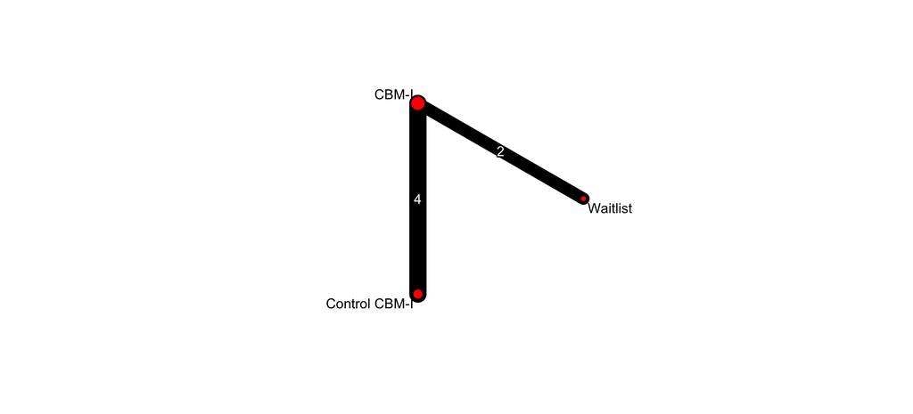

**Figure 17.** Subnetwork plot of CBM interventions contributing data on general anxiety in individuals with social anxiety. CBM-I = Cognitive Bias Modification for Interpretations; Control CBM-I = Control Cognitive Bias Modification for Interpretations

In subnetwork 1 we found effects across CBM interventions versus control CBM-A list to range from 0.11 (SMD, 95% CI: -0.06 to 0.28) in CBM-A to -0.13 (SMD, 95% CI: -0.42 to 0.17) in Opposite CBM-A. The heterogeneity standard deviation is estimated at 0.14.

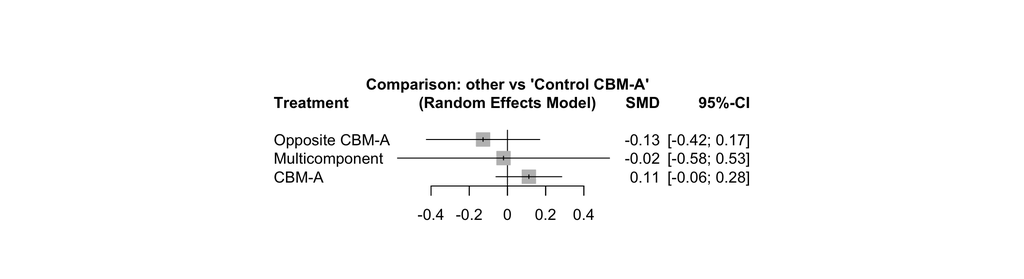

**Figure 18.** Relative treatment effects for general anxiety scores of each intervention versus control CBM-A in subnetwork 1.

In subnetwork 2 we found effects across CBM interventions versus control CBM-I to range from -0.02 (SMD, 95% CI: -0.56 to 0.52) in Waitlist to -0.43 (SMD, 95% CI: -0.73 to -0.13) in CBM-I. The heterogeneity standard deviation is estimated at 0.

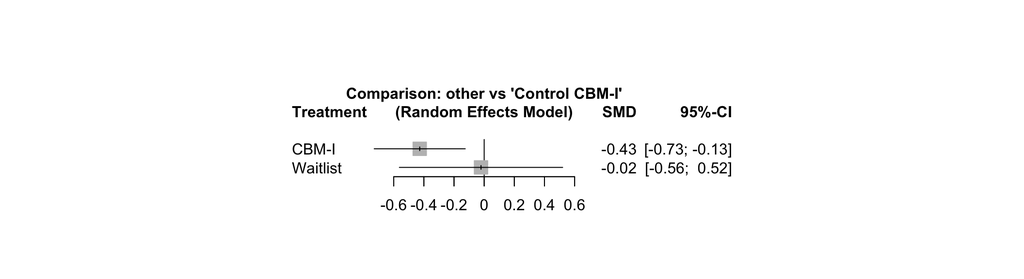

#### 2.3.3.3 Inconsistency assessment

In subnetwork 1. there were in total 3 different treatment comparisons included in a closed loop in the network, and there is inconsistency (according to SIDE p-value<0.10) in 0, equal to 0%.

The p-value from the design-by-treatment test to evaluate global inconsistency for subnetwork 1 is 0.97.

Inconsistency could not be evaluated in subnetwork 2 as there were no closed loops.

#### 2.3.3.4 Risk of bias

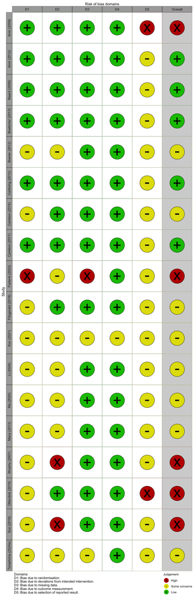

**Figure 20.** Risk of bias assessment for each study contributing data on general anxiety using the RoB2 tool

### 2.3.4 Change in bias

#### 2.3.4.1 Pairwise meta-analysis

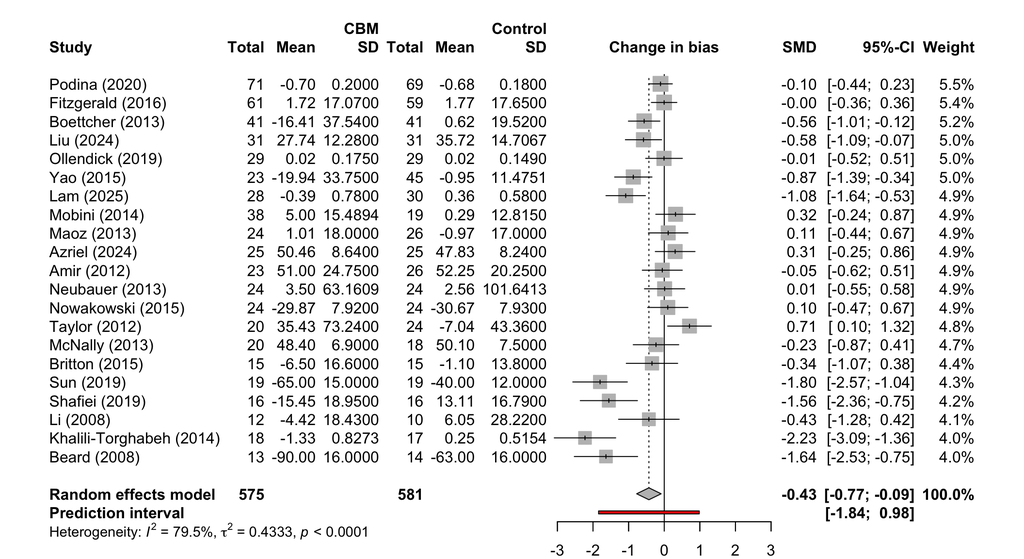

**Figure 21**. Forest plot for change in bias comparing CBM vs control for individuals with social anxiety post intervention . SMD: standardised mean difference, 95% CI: 95% confidence intervals, SD: standard deviation.

The effect of CBM versus control in the clinical source showed a SMD of -0.43 (95% CI: -0.77 to -0.09). There is some heterogeneity as shown by the 95% prediction interval ranging from -1.84 to 0.98.

#### 2.3.4.2 Network meta-analysis

As there was a high amount of heterogeneity in the interventions and controls used in the included studies, network meta-analysis was conducted to establish the relative effects of CBM subtypes and individual controls. The network consisted of 27 studies, 43 comparisons and 9 treatments. In order to construct the network, two studies were removed (Asaani 2014; Bomyea 2023) as they only compared approach avoidance training (AAT) with control AAT and so formed a separate network.

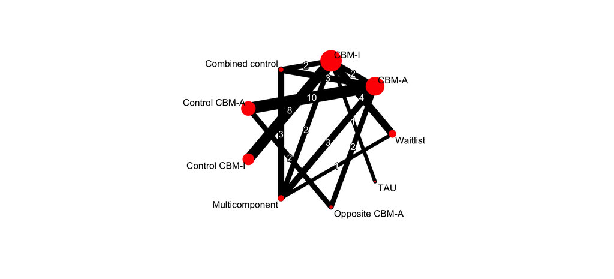

**Figure 22.** Network plot of CBM interventions contributing data on change in bias in individuals with social anxiety. CBM-I = Cognitive Bias Modification for Interpretations; CBM-A = Cognitive Bias Modification for Attention; TAU = Treatment As Usual; Opposite CBM-A = Opposite Cognitive Bias Modification for Attention; Multicomponent = Multicomponent CBM; Control CBM-I; Control CBM-I = Control Cognitive Bias Modification for Interpretations; Control CBM-A = Control Cognitive Bias Modification for Attention.

We found effects across CBM interventions versus control CBM-A to range from 0.8 (SMD, 95% CI: -0.14 to 1.74, 95% PI: -0.65 to 2.26 ) in Control CBM-I to -0.33 (SMD, 95% CI: -0.7 to 0.05, 95% PI: -1.47 to 0.82) in CBM-A. The heterogeneity standard deviation is estimated at 0.52.

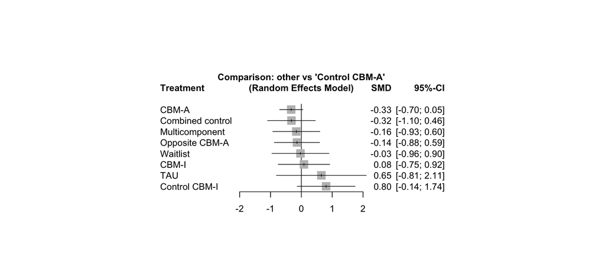

**Figure 23.** Relative treatment effects for change in bias scores of each intervention versus control CBM-A. CBM-I = Cognitive Bias Modification for Interpretations; CBM-A = Cognitive Bias Modification for Attention; TAU = Treatment As Usual; Opposite CBM-A = Opposite Cognitive Bias Modification for Attention; Multicomponent = Multicomponent CBM; Control CBM-I; Control CBM-I = Control Cognitive Bias Modification for Interpretations; Control CBM-A = Control Cognitive Bias Modification for Attention.

All relative treatment effects estimated in the NMA for change in bias scores are presented in the lower triangle of Table 4 (league table).

| . | CBM-A | CBM-I | Combined control | Control CBM-A | Control CBM-I | Multicomponent | Opposite CBM-A | TAU | Waitlist |
| --- | --- | --- | --- | --- | --- | --- | --- | --- | --- |
| CBM-A | CBM-A | -0.54 [-1.39; 0.31] | -0.01 [-0.69; 0.67] | -0.33 [-0.70; 0.04] | NA | -0.16 [-0.84; 0.53] | -0.21 [-1.03; 0.61] | NA | NA |
| CBM-I | -0.41 [-1.16; 0.33], [-1.74; 0.92] | CBM-I | 0.45 [-0.40; 1.30] | NA | -0.72 [-1.14; -0.29] | 0.17 [-0.68; 1.02] | NA | -0.56 [-1.76; 0.63] | 0.09 [-0.50; 0.68] |
| Combined control | -0.01 [-0.69; 0.67], [-1.30; 1.28] | 0.41 [-0.34; 1.15], [-0.93; 1.74] | Combined control | NA | NA | -0.15 [-0.83; 0.54] | NA | NA | NA |
| Control CBM-A | -0.33 [-0.70; 0.05], [-1.47; 0.82] | 0.08 [-0.75; 0.92], [-1.30; 1.47] | -0.32 [-1.10; 0.46], [-1.67; 1.03] | Control CBM-A | NA | NA | 0.16 [-0.66; 0.98] | NA | NA |
| Control CBM-I | -1.13 [-1.99; -0.27], [-2.54; 0.27] | -0.72 [-1.14; -0.29], [-1.88; 0.45] | -1.12 [-1.98; -0.26], [-2.53; 0.28] | -0.80 [-1.74; 0.14], [-2.26; 0.65] | Control CBM-I | NA | NA | NA | NA |
| Multicomponent | -0.17 [-0.83; 0.50], [-1.45; 1.12] | 0.25 [-0.42; 0.92], [-1.04; 1.53] | -0.16 [-0.82; 0.51], [-1.44; 1.12] | 0.16 [-0.60; 0.93], [-1.18; 1.50] | 0.97 [0.17; 1.76], [-0.39; 2.32] | Multicomponent | NA | NA | -0.07 [-1.14; 1.00] |
| Opposite CBM-A | -0.19 [-0.92; 0.55], [-1.51; 1.13] | 0.23 [-0.82; 1.27], [-1.31; 1.76] | -0.18 [-1.18; 0.82], [-1.68; 1.32] | 0.14 [-0.59; 0.88], [-1.18; 1.46] | 0.94 [-0.19; 2.08], [-0.66; 2.55] | -0.02 [-1.01; 0.97], [-1.52; 1.47] | Opposite CBM-A | NA | NA |
| TAU | -0.98 [-2.39; 0.43], [-2.80; 0.85] | -0.56 [-1.76; 0.63], [-2.21; 1.08] | -0.97 [-2.38; 0.44], [-2.80; 0.86] | -0.65 [-2.11; 0.81], [-2.52; 1.22] | 0.15 [-1.11; 1.42], [-1.55; 1.86] | -0.81 [-2.18; 0.55], [-2.60; 0.98] | -0.79 [-2.38; 0.80], [-2.77; 1.19] | TAU | NA |
| Waitlist | -0.30 [-1.15; 0.55], [-1.70; 1.09] | 0.11 [-0.43; 0.65], [-1.10; 1.33] | -0.29 [-1.14; 0.55], [-1.69; 1.10] | 0.03 [-0.90; 0.96], [-1.42; 1.48] | 0.83 [0.14; 1.52], [-0.46; 2.13] | -0.13 [-0.86; 0.59], [-1.45; 1.18] | -0.11 [-1.24; 1.01], [-1.71; 1.48] | 0.68 [-0.63; 1.99], [-1.07; 2.42] | Waitlist |

**Table 4.** League table for change in bias scores. Lower triangle shows the relative treatment effects estimated in the NMA; upper triangle shows the pairwise meta-analysis (direct) estimates. The effects are presented as SMD, 95% CI, and 95% PI. Negative values favour the treatment in the column.

#### 2.3.4.3 Inconsistency assessment

There were in total 9 different treatment comparisons included in loops in the network, and there is inconsistency (according to SIDE p-value<0.10) in 0, equal to 0%.

The p-value from the design-by-treatment test to evaluate global inconsistency is 0.95.

#### 2.3.4.4 Risk of bias

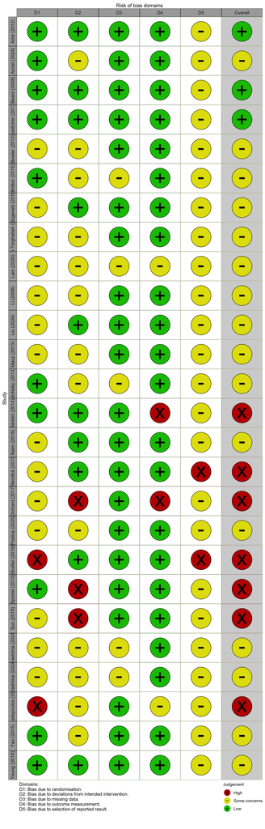

**Figure 24.** Risk of bias assessment for each study contributing data on change in bias using the RoB2 tool

### 2.3.5 Quality of life

#### 2.3.5.1 Pairwise meta-analysis

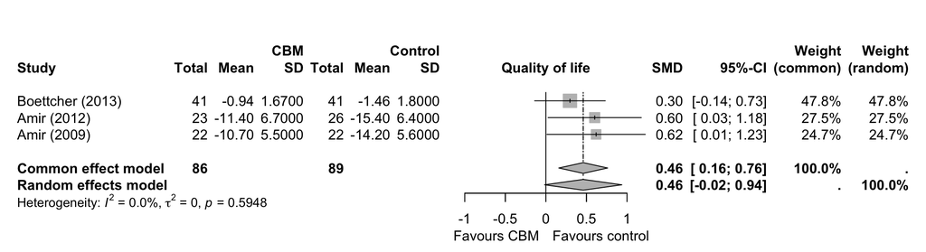

**Figure 25.** Forest plot for quality of life scores comparing CBM versus control post intervention in individuals with social anxiety. SMD: standardised mean difference, 95% CI: 95% confidence intervals, SD: standard deviation.

The effect of CBM versus control in the clinical source showed a SMD of 0.46 (95% CI: -0.02 to 0.94).

#### 2.3.5.2 Network meta-analysis

As there was a high amount of heterogeneity in the interventions and controls used in the included studies, network meta-analysis was conducted to establish the relative effects of CBM subtypes and individual controls. The network consisted of 7 studies, 14 comparisons and 7 treatments. In order to construct the network, two studies were removed (Asaani 2014; Bomyea 2023) as they only compared approach avoidance training (AAT) with control AAT and so formed a separate network.

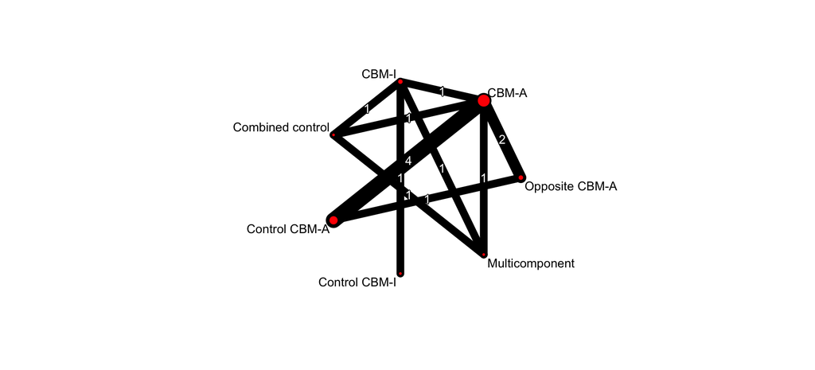

**Figure 26.** Network plot of CBM interventions for quality of life. CBM-I = Cognitive Bias Modification for Interpretations; CBM-A = Cognitive Bias Modification for Attention; TAU = Treatment As Usual; Opposite CBM-I = Opposite Cognitive Bias Modification for Interpretations; Opposite CBM-A = Opposite Cognitive Bias Modification for Attention; Multicomponent = Multicomponent CBM; Control CBM-I; Control CBM-I = Control Cognitive Bias Modification for Interpretations; Control CBM-A = Control Cognitive Bias Modification for Attention.

We found effects across CBM interventions versus control CBM-A to range from 0.38 (SMD, 95% CI: -0.53 to 1.29, 95% PI: -1.69 to 2.45 ) in Opposite CBM-A to -0.51 (SMD, 95% CI: -2.43 to 1.41, 95% PI: -3.67 to 2.66) in Control CBM-I. The heterogeneity standard deviation is estimated at 0.58.

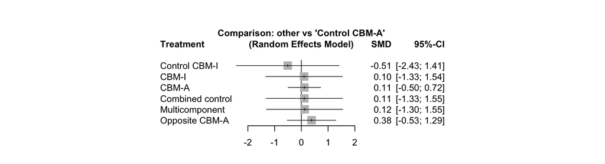

All relative treatment effects estimated in the NMA for quality of life and functioning scores are presented in the lower triangle of Table 5 (league table).

| . | CBM-A | CBM-I | Combined control | Control CBM-A | Control CBM-I | Multicomponent | Opposite CBM-A |
| --- | --- | --- | --- | --- | --- | --- | --- |
| CBM-A | CBM-A | 0.01 [-1.29; 1.31] | 0.00 [-1.30; 1.30] | 0.21 [-0.41; 0.84] | NA | -0.01 [-1.30; 1.28] | -0.32 [-1.18; 0.54] |
| CBM-I | 0.01 [-1.29; 1.31], [-2.44; 2.46] | CBM-I | -0.01 [-1.30; 1.29] | NA | 0.61 [-0.67; 1.89] | -0.02 [-1.31; 1.27] | NA |
| Combined control | 0.00 [-1.30; 1.30], [-2.45; 2.45] | -0.01 [-1.30; 1.29], [-2.45; 2.44] | Combined control | NA | NA | -0.01 [-1.30; 1.28] | NA |
| Control CBM-A | 0.11 [-0.50; 0.72], [-1.72; 1.95] | 0.10 [-1.33; 1.54], [-2.49; 2.70] | 0.11 [-1.33; 1.55], [-2.49; 2.71] | Control CBM-A | NA | NA | 0.11 [-1.11; 1.34] |
| Control CBM-I | 0.62 [-1.20; 2.44], [-2.42; 3.67] | 0.61 [-0.67; 1.89], [-1.82; 3.04] | 0.62 [-1.20; 2.44], [-2.43; 3.66] | 0.51 [-1.41; 2.43], [-2.66; 3.67] | Control CBM-I | NA | NA |
| Multicomponent | -0.01 [-1.30; 1.28], [-2.45; 2.43] | -0.02 [-1.31; 1.27], [-2.46; 2.42] | -0.01 [-1.30; 1.28], [-2.45; 2.43] | -0.12 [-1.55; 1.30], [-2.71; 2.47] | -0.63 [-2.45; 1.18], [-3.67; 2.41] | Multicomponent | NA |
| Opposite CBM-A | -0.27 [-1.09; 0.55], [-2.26; 1.72] | -0.28 [-1.81; 1.25], [-2.99; 2.43] | -0.27 [-1.81; 1.26], [-2.98; 2.44] | -0.38 [-1.29; 0.53], [-2.45; 1.69] | -0.89 [-2.89; 1.11], [-4.15; 2.37] | -0.26 [-1.79; 1.27], [-2.96; 2.44] | Opposite CBM-A |

**Table 5.** League table for quality of life and functioning scores. Lower triangle shows the relative treatment effects estimated in the NMA; upper triangle shows the pairwise meta-analysis (direct) estimates. The effects are presented as SMD, 95% CI, and 95% PI. Negative values favour the treatment in the column.

#### 2.3.5.3 Inconsistency assessment

There are in total 3 different treatment comparisons included in loops in the network, and there was inconsistency (according to SIDE p-value<0.10) in 0 , equal to 0%.

The p-value from the design-by-treatment test to evaluate global inconsistency is 0.02.

#### 2.3.5.4 Risk of bias

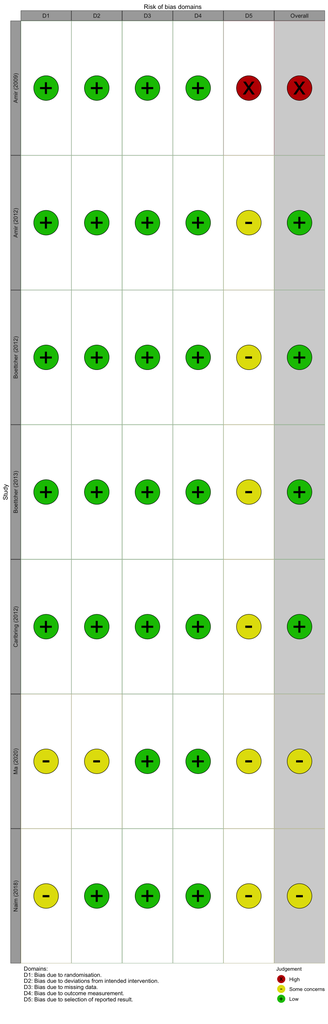

**Figure 28.** Risk of bias assessment for each study contributing data on quality of life using the RoB2 tool

### 2.3.6 Acceptability

#### 2.3.6.1 Pairwise meta-analysis

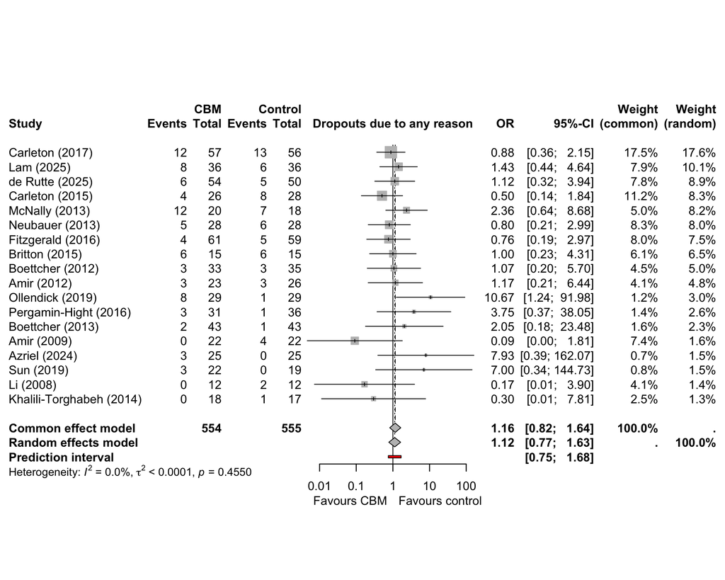

**Figure 29.** Forest plot for acceptability (secondary outcome) comparing CBM versus control post intervention in individuals with social anxiety. OR: odds ratio, 95% CI: 95% confidence intervals, SD: standard deviation.

The effect of CBM versus control in the clinical source showed an OR of 1.12 (95% CI: 0.77 to 1.63). The 95% prediction interval ranged from 0.75 to 1.68.

#### 2.3.6.2 Network meta-analysis

As there was a high amount of heterogeneity in the interventions and controls used in the included studies, network meta-analysis was conducted to establish the relative effects of CBM subtypes and individual controls. The network consisted of 27 studies, 36 comparisons and 9 treatments. In order to construct the network, two studies were removed (Asaani 2014; Bomyea 2023) as they only compared approach avoidance training (AAT) with control AAT and so formed a separate network.

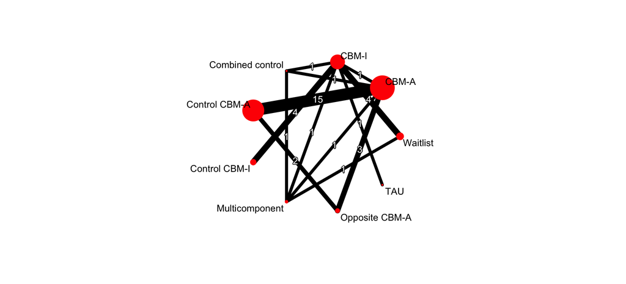

**Figure 30.** Network plot of CBM interventions contributing data on acceptability in individuals with social anxiety. CBM-I = Cognitive Bias Modification for Interpretations; CBM-A = Cognitive Bias Modification for Attention; TAU = Treatment As Usual; Opposite CBM-A = Opposite Cognitive Bias Modification for Attention; Multicomponent = Multicomponent CBM; Control CBM-I; Control CBM-I = Control Cognitive Bias Modification for Interpretations; Control CBM-A = Control Cognitive Bias Modification for Attention.

We found effects across CBM interventions versus Control CBM-A to range from 1.65 (OR, 95% CI: 0.33 to 8.22, 95% PI: 0.3 to 8.99 ) in Combined control to 0.34 (OR, 95% CI: 0.03 to 3.69, 95% PI: 0.03 to 4.22) in TAU. The heterogeneity standard deviation is estimated at 0.

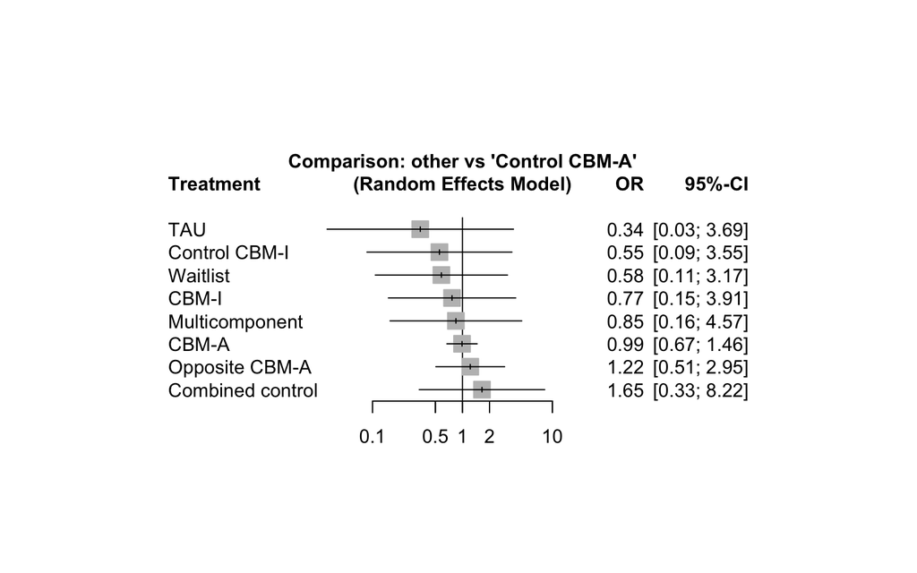

**Figure 31.** Relative treatment effects for acceptability of each intervention versus control CBM-A. CBM-I = Cognitive Bias Modification for Interpretations; CBM-A = Cognitive Bias Modification for Attention; TAU = Treatment As Usual; Opposite CBM-A = Opposite Cognitive Bias Modification for Attention; Multicomponent = Multicomponent CBM; Control CBM-I; Control CBM-I = Control Cognitive Bias Modification for Interpretations; Control CBM-A = Control Cognitive Bias Modification for Attention.

All relative treatment effects estimated in the NMA for acceptability are presented in the lower triangle of Table 6 (league table).

| …1 | CBM-A | CBM-I | Combined control | Control CBM-A | Control CBM-I | Multicomponent | Opposite CBM-A | TAU | Waitlist |
| --- | --- | --- | --- | --- | --- | --- | --- | --- | --- |
| CBM-A | CBM-A | 1.05 [0.19; 5.83] | 0.60 [0.13; 2.85] | 0.99 [0.67; 1.47] | NA | 1.57 [0.24; 10.44] | 1.05 [0.41; 2.64] | NA | NA |
| CBM-I | 1.29 [0.26; 6.30], [0.24; 6.87] | CBM-I | 0.57 [0.12; 2.71] | NA | 1.38 [0.57; 3.36] | 1.50 [0.23; 9.92] | NA | 2.26 [0.39; 12.88] | 1.17 [0.48; 2.88] |
| Combined control | 0.60 [0.13; 2.85], [0.12; 3.11] | 0.46 [0.11; 1.91], [0.10; 2.06] | Combined control | NA | NA | 2.62 [0.46; 15.11] | NA | NA | NA |
| Control CBM-A | 0.99 [0.67; 1.46], [0.66; 1.49] | 0.77 [0.15; 3.91], [0.14; 4.28] | 1.65 [0.33; 8.22], [0.30; 8.99] | Control CBM-A | NA | NA | 0.55 [0.17; 1.75] | NA | NA |
| Control CBM-I | 1.78 [0.29; 10.96], [0.26; 12.13] | 1.38 [0.57; 3.36], [0.54; 3.53] | 2.97 [0.56; 15.78], [0.51; 17.31] | 1.80 [0.28; 11.55], [0.25; 12.80] | Control CBM-I | NA | NA | NA | NA |
| Multicomponent | 1.17 [0.23; 6.04], [0.21; 6.61] | 0.91 [0.33; 2.50], [0.31; 2.65] | 1.95 [0.44; 8.54], [0.41; 9.27] | 1.18 [0.22; 6.39], [0.20; 7.01] | 0.66 [0.17; 2.53], [0.16; 2.73] | Multicomponent | NA | NA | 1.59 [0.71; 3.54] |
| Opposite CBM-A | 0.81 [0.35; 1.90], [0.33; 2.00] | 0.63 [0.10; 3.79], [0.09; 4.19] | 1.35 [0.23; 7.99], [0.21; 8.82] | 0.82 [0.34; 1.98], [0.32; 2.08] | 0.45 [0.06; 3.38], [0.05; 3.78] | 0.69 [0.11; 4.41], [0.10; 4.88] | Opposite CBM-A | NA | NA |
| TAU | 2.91 [0.28; 30.68], [0.24; 34.96] | 2.26 [0.39; 12.88], [0.36; 14.18] | 4.85 [0.52; 45.75], [0.45; 51.81] | 2.94 [0.27; 32.02], [0.24; 36.55] | 1.63 [0.23; 11.55], [0.21; 12.87] | 2.49 [0.33; 18.71], [0.30; 20.92] | 3.59 [0.29; 43.99], [0.26; 50.55] | TAU | NA |
| Waitlist | 1.70 [0.33; 8.82], [0.30; 9.66] | 1.31 [0.58; 2.99], [0.55; 3.13] | 2.83 [0.64; 12.48], [0.59; 13.55] | 1.71 [0.32; 9.32], [0.29; 10.24] | 0.95 [0.28; 3.20], [0.26; 3.42] | 1.45 [0.69; 3.07], [0.66; 3.20] | 2.09 [0.33; 13.39], [0.30; 14.85] | 0.58 [0.08; 4.00], [0.08; 4.45] | Waitlist |

**Table 6.** League table for acceptability. Lower triangle shows the relative treatment effects estimated in the NMA; upper triangle shows the pairwise meta-analysis (direct) estimates. The effects are presented as OR, 95% CI, and 95% PI. OR < 1 favours treatment in the column, OR > 1 favours treatment in the row.